# practice_3

2/11/2020

## Today’s lab: **gapminder data**

```r
library(tidyverse)
library(gapminder)
data("gapminder")
str(gapminder)
```

```
## Classes 'tbl_df', 'tbl' and 'data.frame':    1704 obs. of  6 variables:
##  $ country  : Factor w/ 142 levels "Afghanistan",..: 1 1 1 1 1 1 1 1 1 1 ...
##  $ continent: Factor w/ 5 levels "Africa","Americas",..: 3 3 3 3 3 3 3 3 3 3 ...
##  $ year     : int  1952 1957 1962 1967 1972 1977 1982 1987 1992 1997 ...
##  $ lifeExp  : num  28.8 30.3 32 34 36.1 ...
##  $ pop      : int  8425333 9240934 10267083 11537966 13079460 14880372 12881816 13867957 16317921 22227415 ...
##  $ gdpPercap: num  779 821 853 836 740 ...
```

## Data Exploration: Gapminder

- Use the following codes to obtain basic information: str(), names(), ncol(), length(), dim(), nrow(), summary(), head()
- Create plots

## Data Exploration: Gapminder

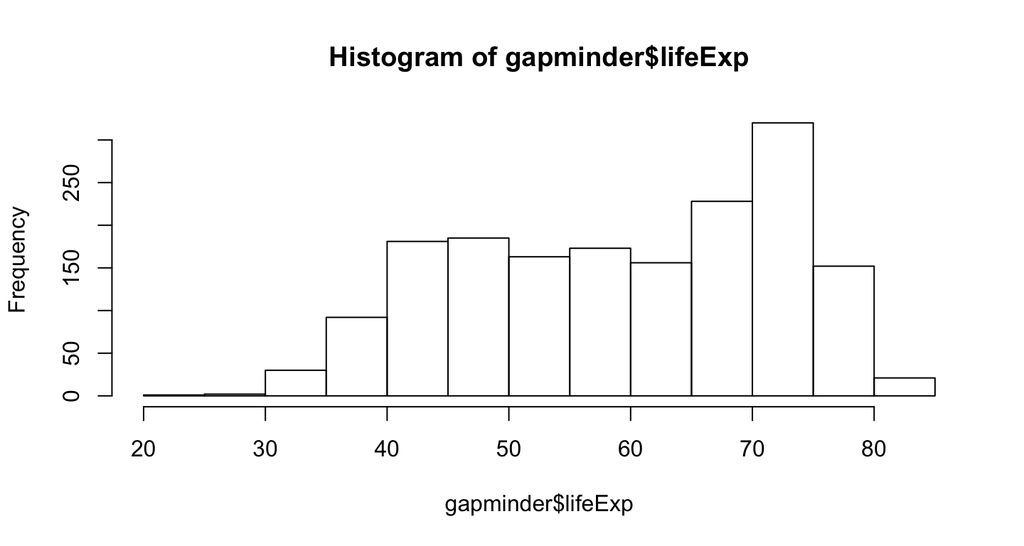

```r
hist(gapminder$lifeExp)
```

## Data Exploration: Gapminder

```r
table(gapminder$continent)
```

```
##
##   Africa Americas     Asia   Europe  Oceania
##      624      300      396      360       24
```

## Data Exploration: Gapminder

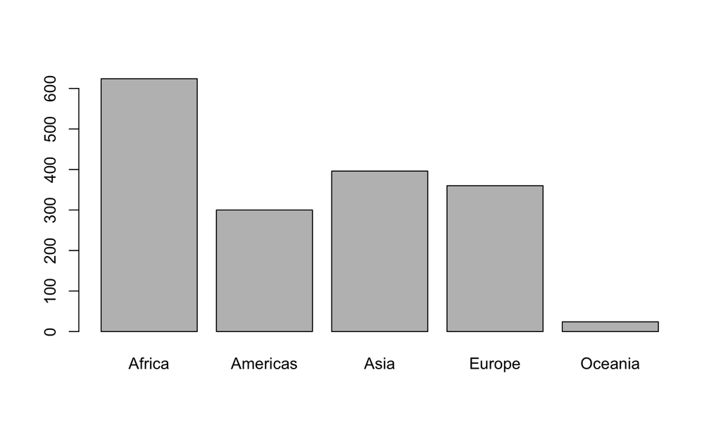

```r
continent_table<-table(gapminder$continent)
barplot(continent_table)
```

## Data Exploration: Gapminder

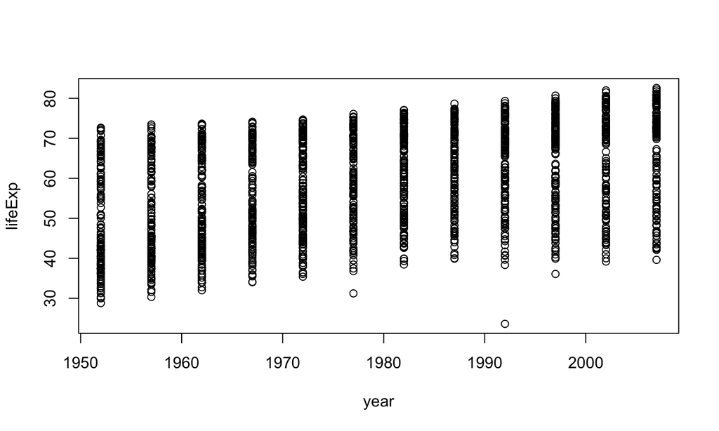

```r
plot(lifeExp ~ year, gapminder)
```

## Data Exploration: Gapminder

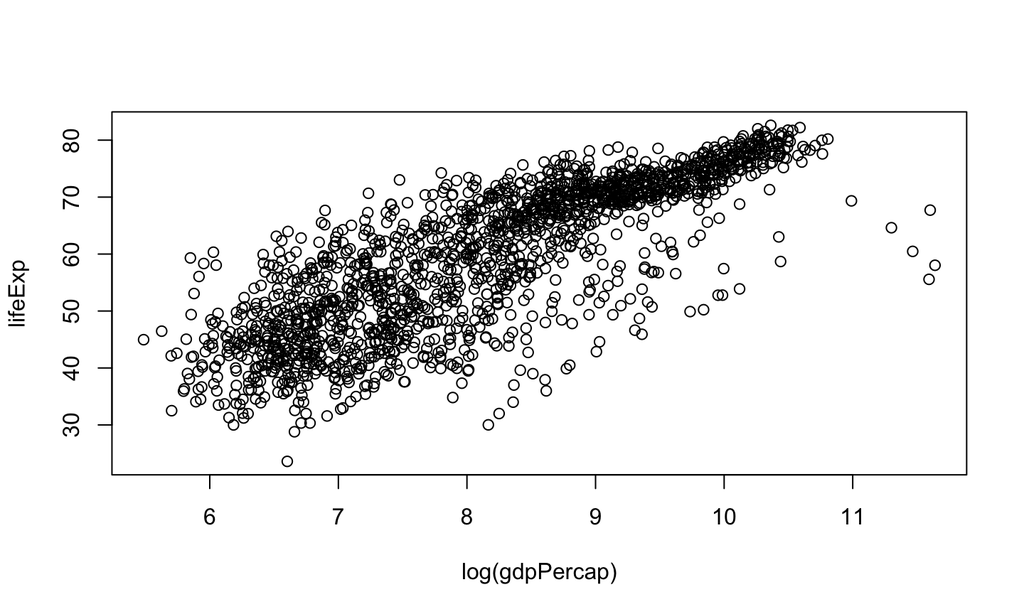

```r
plot(lifeExp ~ log(gdpPercap), gapminder)
```

## Exercise

- Create a data frame that includes only cases from **Rwanda** until the year 1979

(We should all remember this exercise from last week)

## Piping

- useful to rewrite a fairly short linear sequence of operations
- the pipe operation: **%>%**
- Packages in tidyverse load **%>%** automatically
- Today’s lab: *gapminder* data

## Piping - exercise

- Subset the “gapminder” dataset including only year and life-expectancy, and obtain a summary of these two variables using the pipe operator

## Results

```r
gapminder %>%
  select(year, lifeExp) %>%
  summary()
```

```
##       year         lifeExp
##  Min.   :1952   Min.   :23.60
##  1st Qu.:1966   1st Qu.:48.20
##  Median :1980   Median :60.71
##  Mean   :1980   Mean   :59.47
##  3rd Qu.:1993   3rd Qu.:70.85
##  Max.   :2007   Max.   :82.60
```

## Piping- Exercise

- Obtain a tibble that includes only year and life expectancy in Cambodia (ONLY!)

## Results

```r
gapminder %>%
  filter(country== "Cambodia") %>%
  select(year, lifeExp)
```

```
## # A tibble: 12 x 2
##     year lifeExp
##    <int>   <dbl>
##  1  1952    39.4
##  2  1957    41.4
##  3  1962    43.4
##  4  1967    45.4
##  5  1972    40.3
##  6  1977    31.2
##  7  1982    51.0
##  8  1987    53.9
##  9  1992    55.8
## 10  1997    56.5
## 11  2002    56.8
## 12  2007    59.7
```

## Exercise

- Create a new variable labeled “gdp” (*Gross domestic product*). GDP is the product of population and “gdpPercap”, using the pipe operation
- Using the pipe operation, provide the median life expectancy based on continents in year 2007.

## Results 1

```r
gapminder %>%
  mutate(gdp = pop* gdpPercap)
```

```
## # A tibble: 1,704 x 7
##    country     continent  year lifeExp      pop gdpPercap          gdp
##    <fct>       <fct>     <int>   <dbl>    <int>     <dbl>        <dbl>
##  1 Afghanistan Asia       1952    28.8  8425333      779.  6567086330.
##  2 Afghanistan Asia       1957    30.3  9240934      821.  7585448670.
##  3 Afghanistan Asia       1962    32.0 10267083      853.  8758855797.
##  4 Afghanistan Asia       1967    34.0 11537966      836.  9648014150.
##  5 Afghanistan Asia       1972    36.1 13079460      740.  9678553274.
##  6 Afghanistan Asia       1977    38.4 14880372      786. 11697659231.
##  7 Afghanistan Asia       1982    39.9 12881816      978. 12598563401.
##  8 Afghanistan Asia       1987    40.8 13867957      852. 11820990309.
##  9 Afghanistan Asia       1992    41.7 16317921      649. 10595901589.
## 10 Afghanistan Asia       1997    41.8 22227415      635. 14121995875.
## # … with 1,694 more rows
```

## Results 2

```r
gapminder %>%
    filter(year == 2007) %>%
    group_by(continent) %>%
    summarise(lifeExp = median(lifeExp))
```

```
## # A tibble: 5 x 2
##   continent lifeExp
##   <fct>       <dbl>
## 1 Africa       52.9
## 2 Americas     72.9
## 3 Asia         72.4
## 4 Europe       78.6
## 5 Oceania      80.7
```

## Exercises

- Look at the data from year 2007, sorted on life expectancy (use **arrange()**)
- Look at the data from year 2007, sorted on life expectancy in descending order.

## Results

```r
gapminder %>%
  filter(year== 2007) %>%
  arrange(desc(lifeExp))
```

```
## # A tibble: 142 x 6
##    country          continent  year lifeExp       pop gdpPercap
##    <fct>            <fct>     <int>   <dbl>     <int>     <dbl>
##  1 Japan            Asia       2007    82.6 127467972    31656.
##  2 Hong Kong, China Asia       2007    82.2   6980412    39725.
##  3 Iceland          Europe     2007    81.8    301931    36181.
##  4 Switzerland      Europe     2007    81.7   7554661    37506.
##  5 Australia        Oceania    2007    81.2  20434176    34435.
##  6 Spain            Europe     2007    80.9  40448191    28821.
##  7 Sweden           Europe     2007    80.9   9031088    33860.
##  8 Israel           Asia       2007    80.7   6426679    25523.
##  9 France           Europe     2007    80.7  61083916    30470.
## 10 Canada           Americas   2007    80.7  33390141    36319.
## # … with 132 more rows
```

## Group_by

- You can use **group_by()** to produce similar results as **table()**

```r
gapminder %>%
  group_by(continent) %>%
  summarize (n= n())
```

```
## # A tibble: 5 x 2
##   continent     n
##   <fct>     <int>
## 1 Africa      624
## 2 Americas    300
## 3 Asia        396
## 4 Europe      360
## 5 Oceania      24
```

```r
gapminder %>%
  summarize(n=n(),
            n_countries = n_distinct(country))
```

```
## # A tibble: 1 x 2
##       n n_countries
##   <int>       <int>
## 1  1704         142
```

## Functions that apply within summarize ()

- mean()
- median()
- var ()
- sd ()
- IQR ()
- min()
- max()

## merging data

- “superheros”

```r
superheroes <- tibble::tribble(
       ~name, ~alignment,  ~gender,          ~publisher,
   "Magneto",      "bad",   "male",            "Marvel",
     "Storm",     "good", "female",            "Marvel",
  "Mystique",      "bad", "female",            "Marvel",
    "Batman",     "good",   "male",                "DC",
     "Joker",      "bad",   "male",                "DC",
  "Catwoman",      "bad", "female",                "DC",
   "Hellboy",     "good",   "male", "Dark Horse Comics"
  )
```

## merging data

- “publishers”

```r
publishers <- tibble::tribble(
  ~publisher, ~yr_founded,
        "DC",       1934L,
    "Marvel",       1939L,
     "Image",       1992L
  )
```

## inner_join (superheroes, publishers)

- inner_join (x,y): return all rows from x where there are matching values in y, and all columns from x and y.
- If there are multiple matches between x and y, all combination of the matches are returned.

## example

```r
(joined <- inner_join(superheroes, publishers))
```

```
## # A tibble: 6 x 5
##   name     alignment gender publisher yr_founded
##   <chr>    <chr>     <chr>  <chr>          <int>
## 1 Magneto  bad       male   Marvel          1939
## 2 Storm    good      female Marvel          1939
## 3 Mystique bad       female Marvel          1939
## 4 Batman   good      male   DC              1934
## 5 Joker    bad       male   DC              1934
## 6 Catwoman bad       female DC              1934
```

## inner_join

Observe what had happened.

## left_join (superheroes, publishers)

- left_join(x, y): return all rows from x, and all columns from x and y. If there are multiple matches between x and y, all combination of the matches are returned. **mutating join**

```r
(left <- left_join(superheroes, publishers))
```

```
## # A tibble: 7 x 5
##   name     alignment gender publisher         yr_founded
##   <chr>    <chr>     <chr>  <chr>                  <int>
## 1 Magneto  bad       male   Marvel                  1939
## 2 Storm    good      female Marvel                  1939
## 3 Mystique bad       female Marvel                  1939
## 4 Batman   good      male   DC                      1934
## 5 Joker    bad       male   DC                      1934
## 6 Catwoman bad       female DC                      1934
## 7 Hellboy  good      male   Dark Horse Comics         NA
```

## Exercise

- What can you observe when you use semi_join(x, y)?
- What can you observe when you use anti_join(x, y)?
- What can you observe when you use full_join(x, y)?

## Greate mini gapminder

```r
mini_gap <- gapminder %>%
  filter(country %in% c("Belgium", "Canada", "United States", "Mexico"),
         year > 2000) %>%
  select(-pop, -gdpPercap) %>%
  droplevels() ## drop unused levels from factor variables
mini_gap
```

```
## # A tibble: 8 x 4
##   country       continent  year lifeExp
##   <fct>         <fct>     <int>   <dbl>
## 1 Belgium       Europe     2002    78.3
## 2 Belgium       Europe     2007    79.4
## 3 Canada        Americas   2002    79.8
## 4 Canada        Americas   2007    80.7
## 5 Mexico        Americas   2002    74.9
## 6 Mexico        Americas   2007    76.2
## 7 United States Americas   2002    77.3
## 8 United States Americas   2007    78.2
```

## Greate a table of national foods

```r
food <- tribble(
        ~ country,    ~ food,
        "Belgium",  "waffle",
         "Canada", "poutine",
  "United States", "Twinkie"
)
food
```

```
## # A tibble: 3 x 2
##   country       food
##   <chr>         <chr>
## 1 Belgium       waffle
## 2 Canada        poutine
## 3 United States Twinkie
```

## merge using left_join

- match(x, table): reports where the values in the key **x** appear in the lookup variable table.

```r
mini_gap %>%
  left_join(food)
```

```
## # A tibble: 8 x 5
##   country       continent  year lifeExp food
##   <chr>         <fct>     <int>   <dbl> <chr>
## 1 Belgium       Europe     2002    78.3 waffle
## 2 Belgium       Europe     2007    79.4 waffle
## 3 Canada        Americas   2002    79.8 poutine
## 4 Canada        Americas   2007    80.7 poutine
## 5 Mexico        Americas   2002    74.9 <NA>
## 6 Mexico        Americas   2007    76.2 <NA>
## 7 United States Americas   2002    77.3 Twinkie
## 8 United States Americas   2007    78.2 Twinkie
```